# Sparcc Simulation 1

Brian Richardson

03/27/2024

```r
rm(list = ls())
library(dplyr)
library(tidyverse)
library(ggplot2)
library(ggh4x)
library(scales)
library(ggthemes)
library(kableExtra)
```

## Simulation Setup

The goal of this program is to evaluate the performance of the semiparametric efficient estimator $\widehat{\pmb{\beta}}$ using simulations in the following setting:

- $X|Z \sim \textrm{gamma}(\theta_1, \theta_2)$,
- $C|Z \sim \textrm{gamma}(\gamma_1, \gamma_2)$,
- $Y|X,Z \sim N(\beta_0 + \beta_1X + \beta_2Z, \sigma^2)$.

The assumption that $Y|X,Z$ follows a normal distribution allows us to use Gaussian quadrature to efficiently solve integrals with respect to $y$.

In these simulations, we vary the censoring probability $q=\textrm{P}(X>C)$.

We also vary which nuisance distributions are correct by modeling $X|Z$ (or $C|Z$) as gamma (correct) or exponential (incorrect).

For each simulation, we generate a data set of size $n$ then compute the complete case estimator $\widehat{\pmb{\beta}}_{cc}$, the oracle estimator $\widehat{\pmb{\beta}}_{or}$, the parametric MLE $\widehat{\pmb{\beta}}_{ml}$, and the semiparametric efficient estimator $\widehat{\pmb{\beta}}$.

## Computing the Semiparametric Estimator

Our current approach for computing $S_{eff}$ is as follows.

- Approximate the integral equation in Proposition 3 using quadrature rules for $X$ and $C$. In particular, assign point mass $r_j = \eta_1^*(x_j, \widehat\alpha_1) / \sum_{k=1}^{m_x} \eta_1^*(x_k, \widehat\alpha_1)$ to each of $m_x$ nodes $x_j$ in the support of $X$, and point mass $t_j = \eta_2^{\dagger}(c_j, \widehat\alpha_2) / \sum_{k=1}^{m_c} \eta_2^{\dagger}(c_k, \widehat\alpha_2)$ to each of $m_c$ nodes $c_j$ in the support of $C$.
- Replace all integrals with respect to $x$ or $c$ with finite sums, using the above quadrature rules. For example, in $\textrm{LHS}_j$, we let $\textrm{E}\{\textrm{I}(x_j\leq C\} = \int_{x_j}^\infty\eta_2(c)\approx\sum_{k=1}^{m_c}t_k\textrm{I}(c_k\geq x_j)$.
- Evaluate integrals with respect to $y$ using Gaussian quadrature using $m_y$ nodes. Let $w_h, \phi_h$ be the nodes and weights for the integral approximation $\int g(u)\exp(-u^2)du \approx \sum_{h=1}^{m_y}g(w_h)\phi_h$. Then all integrals with $f_{Y|X}(y,x_i,\pmb{\beta}, \sigma^2)$ or $f_{Y|X}(y,x_i,\pmb{\beta}, \sigma^2)f_{Y|X}(y,x_j,\pmb{\beta}, \sigma^2)$ in the integrand can be approximated using:

$$\int g(y)f_{Y|X}(y,x_i,\pmb{\beta}, \sigma^2)dy \\
= \int
g(y)(2\pi\sigma^2)^{-1/2}\exp\left\{-\frac{1}{2\sigma^2}(y-\mu_i)^2\right\}dy
\\
= \pi^{-1/2}\int g(\sqrt{2}\sigma u + \mu_i)\exp(-u^2)du \\
\approx \pi^{-1/2}\sum_{h=1}^{m_y}g(\sqrt{2}\sigma w_h + \mu_i)\phi_h,$$

and

$$\int g(y)f_{Y|X}(y,x_i,\pmb{\beta}, \sigma^2)f_{Y|X}(y,x_j,\pmb{\beta},
\sigma^2)dy \\
= \int g(y)(2\pi,
\sigma^2)^{-1}\exp\left\{-\frac{1}{4\sigma^2}(\mu_i-\mu_j)^2\right\}\exp\{-\frac{1}{\sigma^2}(y-\bar{\mu}_{ij})^2dy
\\
=
(2\pi\sigma)^{-1}\exp\left\{-\frac{1}{4\sigma^2}(\mu_i-\mu_j)^2\right\}\int
g(\sigma u + \bar{\mu}_{ij})\exp(-u^2)du \\
\approx
(2\pi\sigma)^{-1}\exp\left\{-\frac{1}{4\sigma^2}(\mu_i-\mu_j)^2\right\}\sum_{h=1}^{m_y}g(\sigma
w_h + \bar{\mu}_{ij})\phi_h.$$

- Solve for $\eta_1^*(x_j, \widehat\alpha_1)\pmb{a}(x_j, \pmb{\beta})$ at each node $x_j$. This involves solving a symmetric system of linear equations, which is done stably and quickly using the Cholesky decomposition. Then use linear interpolation to evaluate $\eta_1^*(x, \widehat\alpha_1)\pmb{a}(x,\pmb{\beta})$ at any observed $x$ value that is not a node in the quadrature rule for $X$.
- Use the obtained $\pmb{a}(x,\pmb{\beta},\sigma^2)$ values and the quadrature rules for $X$ and $C$ to approximate the efficient score vector $S_{eff}$, evaluated at the observed data $(y_i,w_i,\delta_i)$ for each observation $i$.
- In a previous set of simulations, we showed that $m_y=2$ and $m_c=15$ are sufficiently fine grids for approximating $S_{eff}$, and that $m_x$ may need to be as large as $100$. We will use these values for now.

## Simulation Results

We first look at which simulation settings lead to errors.

```r
# true (beta0, beta2)
B13 <- c(1, NA, 2, NA)

# load simulation results from each of 10 clusters
sim.out.list <- lapply(
  X = 0:9,
  FUN = function(clust) {
    cbind(clust,
          read.csv(paste0(
            "sim1_data/v5/sd",
            clust, ".csv")))
  })

# combine simulation results into 1 data frame
sim.out <- bind_rows(sim.out.list)

colnames(sim.out) <- gsub(".B", "", colnames(sim.out))
colnames(sim.out) <- gsub("B2", "trueB2", colnames(sim.out))

# make long data frame
sim.out.long <- sim.out %>%
  pivot_longer(cols = starts_with("B"),
               names_to = "method.param",
               values_to = "estimate") %>%
    mutate(method = factor(substr(method.param, 2, 3),
                           levels = c("or", "cc", "ml", "sp")),
           specify.x.gamma = factor(specify.x.gamma,
                                    levels = c(1, 0)),
           specify.c.gamma = factor(specify.c.gamma,
                                    levels = c(1, 0)),
           param = factor(substr(method.param, 4, 4)),
           B.true = ifelse(param == 2, trueB2,
                    ifelse(param == 4, log(s2),
                           B13[param])))
```

```r
# check for simulations with errors
sim.out.long %>%
  filter(param == 1) %>%
  group_by(q, n, specify.x.gamma, specify.c.gamma, method, trueB2, s2) %>%
  summarize(prop.error = mean(is.na(estimate))) %>%
  filter(prop.error > 0) %>%
  kable(digits = 3) %>%
  kable_styling("striped")
```

| q | n | specify.x.gamma | specify.c.gamma | method | trueB2 | s2 | prop.error |
| --- | --- | --- | --- | --- | --- | --- | --- |
| 0.7 | 8000 | 0 | 1 | ml | 1 | 0.16 | 0.01 |
| 0.7 | 8000 | 0 | 0 | ml | 1 | 0.16 | 0.01 |

```r
# extract simulation parameters
q <- unique(sim.out$q)
n <- unique(sim.out$n)
s2 <- unique(sim.out$s2)
trueB2 <- unique(sim.out$trueB2)
specify.x.gamma <- unique(sim.out$specify.x.gamma)
specify.c.gamma <- unique(sim.out$specify.c.gamma)
mx <- unique(sim.out$mx)
mc <- unique(sim.out$mc)
my <- unique(sim.out$my)
n.rep <- nrow(sim.out) /
  n_distinct(dplyr::select(sim.out, q, n, specify.x.gamma, specify.c.gamma, mx, mc, my, s2, trueB2))

# make labels for plots
method.labs <- c("Oracle",
                 "Complete Case",
                 "Parametric MLE",
                 "Semiparametric")

names(method.labs) <- c("or", "cc", "ml", "sp")

q.labs <- paste0("q = ", q)
names(q.labs) <- q

n.labs <- paste0("n = ", n)
names(n.labs) <- n

s2.labs <- paste0("s2 = ", s2)
names(s2.labs) <- s2

trueB2.labs <- paste0("B2 = ", trueB2)
names(trueB2.labs) <- trueB2

specx.labs <- c("X Correct", "X Incorrect")
names(specx.labs) <- specify.x.gamma

specc.labs <- c("C Correct", "C Incorrect")
names(specc.labs) <- specify.c.gamma

mx.labs <- paste0("mx = ", mx)
names(mx.labs) <- mx

mc.labs <- paste0("mc = ", mc)
names(mc.labs) <- mc

my.labs <- paste0("my = ", my)
names(my.labs) <- my

param.labs <- c("\u03B20", "\u03B21", "\u03B22", "log\u03C3\u00B2")

# colorblind friendly pallette
#pal_light <- cbbPalette <- c('#BBBBBB', '#228833', '#4477AA', '#AA3377')
#pal_dark <- cbbPalette <- c('#5d5d5d', '#114419', '#223b55', '#55193b')
pal_light <- c('#EE6677', '#228833', '#4477AA', '#CCBB44', '#66CCEE', '#AA3377', '#BBBBBB')
pal_dark <- c('#991122', '#114419', '#223b55', '#6b611d', '#117799', '#55193b', '#5d5d5d')
```

```r
# boxplot of simulated estimates
make.est.plot <- function(param., q., est_cutoff = Inf) {

  sim.out.long %>%
    filter(param == param.,
           q == q.,
           abs(estimate - B.true) < est_cutoff) %>%
    ggplot(aes(y = estimate,
               color = method,
               fill = method)) +
    geom_boxplot() +
    geom_hline(aes(yintercept = B.true),
               linetype = "dashed",
               linewidth = 0.6,
               color = pal_light[4]) +
    facet_nested(trueB2 ~ specify.x.gamma + specify.c.gamma,
                 scales = "free",
                 labeller = labeller(n = n.labs,
                                     q = q.labs,
                                     trueB2 = trueB2.labs,
                                     #s2 = s2.labs,
                                     specify.x.gamma = specx.labs,
                                     specify.c.gamma = specc.labs)) +
    labs(y = "Parameter Estimate",
         fill = "Method",
         color = "Method") +
    ggtitle(paste0("Empirical Distribution of Parameter Estimates for ",
                   param.labs[param.]),
            subtitle = paste0("censoring proportion q = ", q., "; ",
                              n.rep, " replicates per setting")) +
    theme_bw() +
    theme(axis.ticks.x = element_blank(),
          axis.text.x = element_blank(),
          axis.title.x = element_blank()) +
    scale_fill_manual(values = pal_light[c(1, 2, 3, 5, 6)],
                      labels = method.labs) +
    scale_color_manual(values = pal_dark[c(1, 2, 3, 5, 6)],
                      labels = method.labs)
}
```

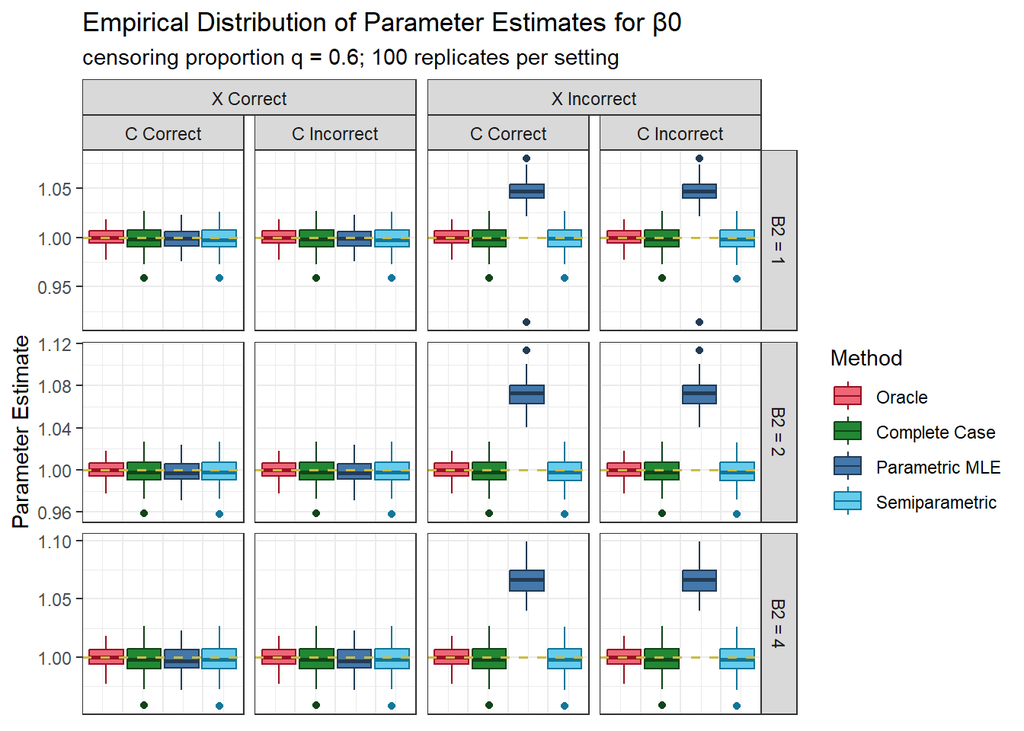

```r
make.est.plot(param. = 1, q. = q[1])
```

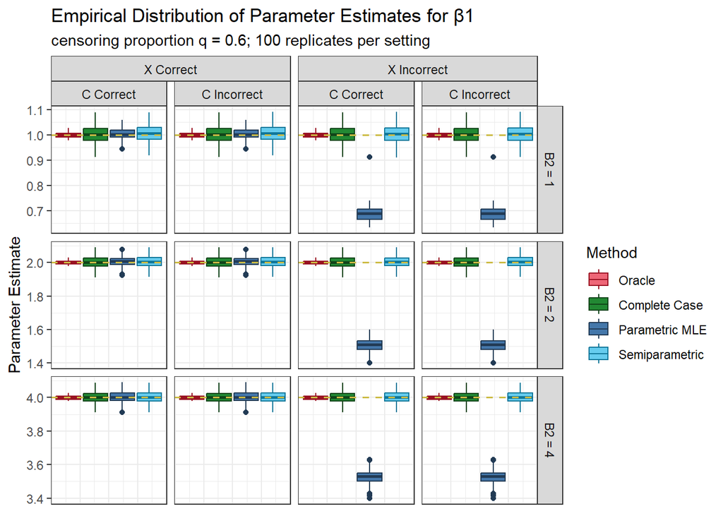

```r
make.est.plot(param. = 2, q. = q[1])
```

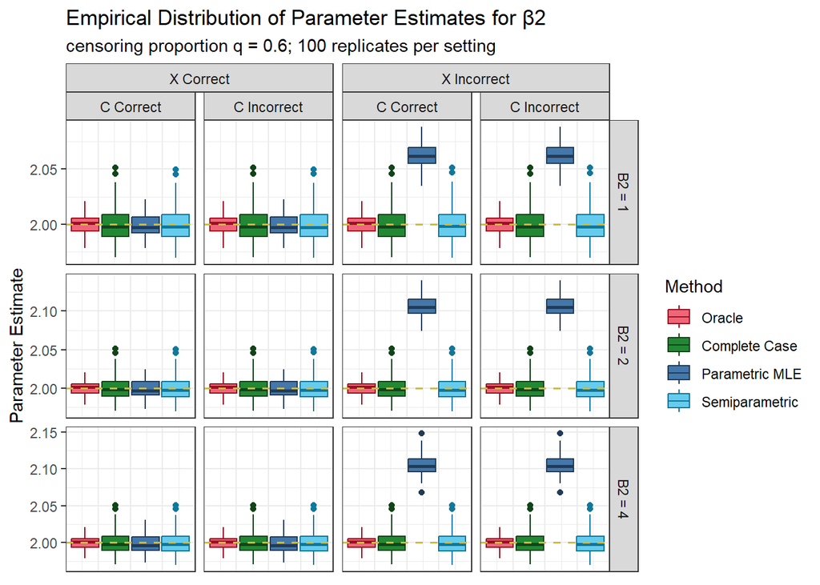

```r
make.est.plot(param. = 3, q. = q[1])
```

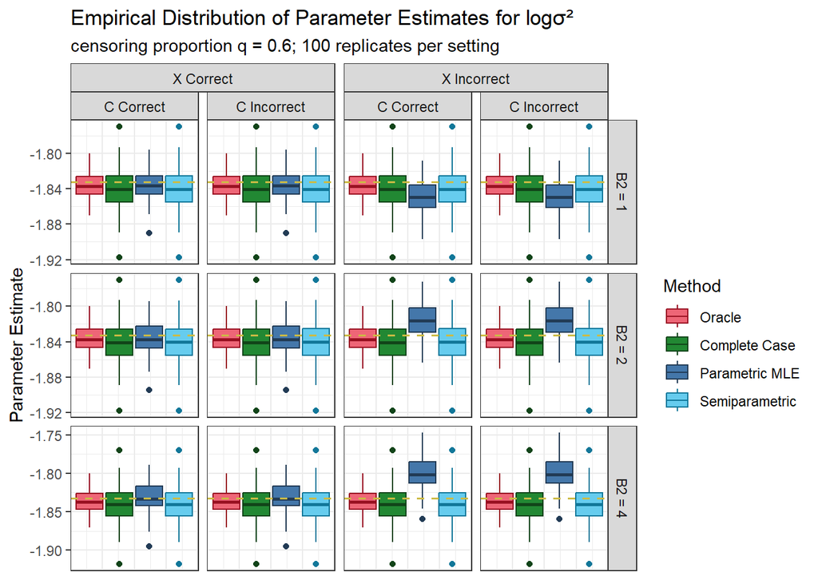

```r
make.est.plot(param. = 4, q. = q[1], est_cutoff = 2)
```

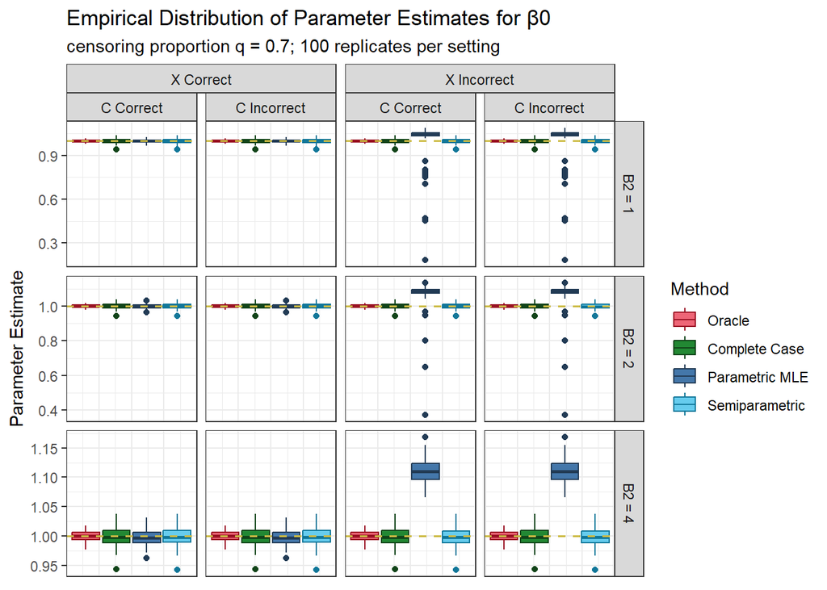

```r
make.est.plot(param. = 1, q. = q[2], est_cutoff = 1)
```

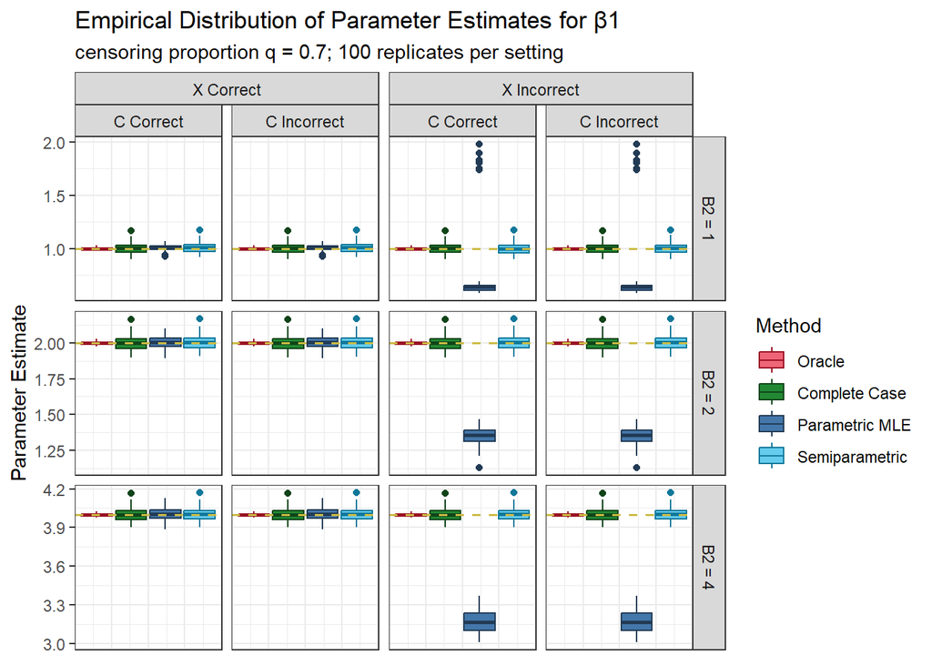

```r
make.est.plot(param. = 2, q. = q[2], est_cutoff = 1)
```

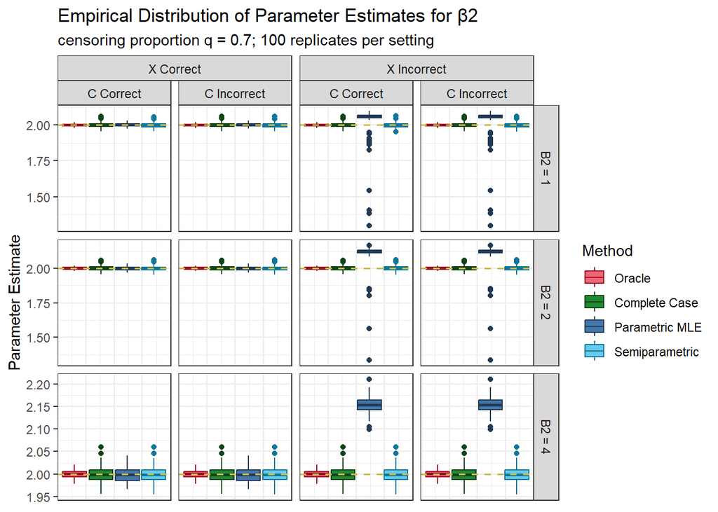

```r
make.est.plot(param. = 3, q. = q[2], est_cutoff = 1)
```

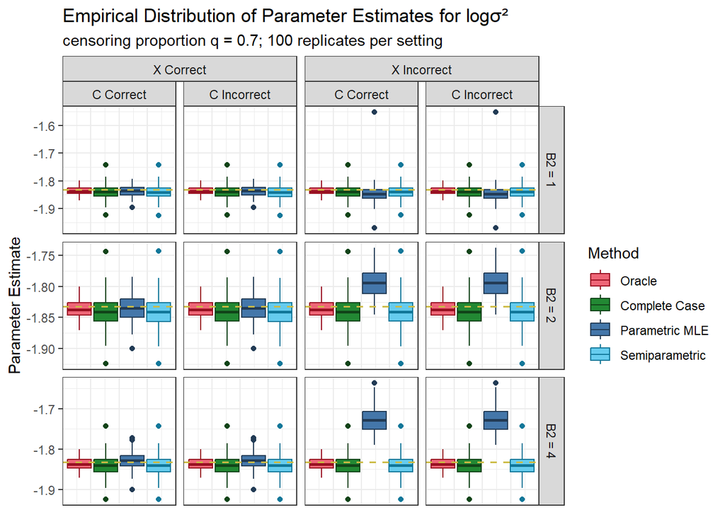

```r
make.est.plot(param. = 4, q. = q[2], est_cutoff = 2)
```

```r
tbl <- sim.out.long %>%
  group_by(n, q, s2, trueB2, specify.x.gamma, specify.c.gamma, method, param) %>%
  summarise(bias = 100*mean(estimate - B.true, na.rm = T),
            emp.se = 100*sd(estimate, na.rm = T),
            mse = 100*mean((estimate - B.true) ^ 2, na.rm = T)) %>%
  gather(key, value, bias:mse) %>%
  unite(Group, param, key) %>%
  spread(Group, value)
```

```
## 'specify.x.gamma', 'specify.c.gamma', 'method'. You can override using the
```

```r
setNames(tbl, sub(".+_", "", names(tbl))) %>%
  kable(digits = 2) %>%
  kable_styling("striped") %>%
  add_header_above(c(" " = 7,
                     "beta_0" = 3,
                     "beta_1" = 3,
                     "beta_2" = 3,
                     "log(var)" = 3))
```

| n | q | s2 | trueB2 | specify.x.gamma | specify.c.gamma | method | beta_0 bias | beta_0 emp.se | beta_0 mse | beta_1 bias | beta_1 emp.se | beta_1 mse | beta_2 bias | beta_2 emp.se | beta_2 mse | log(var) bias | log(var) emp.se | log(var) mse |
| --- | --- | --- | --- | --- | --- | --- | --- | --- | --- | --- | --- | --- | --- | --- | --- | --- | --- | --- |
| 8000 | 0.6 | 0.16 | 1 | 1 | 1 | or | 0.03 | 0.77 | 0.01 | -0.07 | 1.12 | 0.01 | 0.00 | 0.86 | 0.01 | -0.42 | 1.42 | 0.02 |
| 8000 | 0.6 | 0.16 | 1 | 1 | 1 | cc | -0.13 | 1.27 | 0.02 | 0.26 | 3.80 | 0.14 | 0.02 | 1.59 | 0.03 | -0.83 | 2.31 | 0.06 |
| 8000 | 0.6 | 0.16 | 1 | 1 | 1 | ml | -0.10 | 1.01 | 0.01 | 0.34 | 2.22 | 0.05 | -0.09 | 1.01 | 0.01 | -0.38 | 1.69 | 0.03 |
| 8000 | 0.6 | 0.16 | 1 | 1 | 1 | sp | -0.17 | 1.27 | 0.02 | 0.67 | 3.68 | 0.14 | -0.02 | 1.58 | 0.02 | -0.82 | 2.32 | 0.06 |
| 8000 | 0.6 | 0.16 | 1 | 1 | 0 | or | 0.03 | 0.77 | 0.01 | -0.07 | 1.12 | 0.01 | 0.00 | 0.86 | 0.01 | -0.42 | 1.42 | 0.02 |
| 8000 | 0.6 | 0.16 | 1 | 1 | 0 | cc | -0.13 | 1.27 | 0.02 | 0.26 | 3.80 | 0.14 | 0.02 | 1.59 | 0.03 | -0.83 | 2.31 | 0.06 |
| 8000 | 0.6 | 0.16 | 1 | 1 | 0 | ml | -0.10 | 1.01 | 0.01 | 0.34 | 2.22 | 0.05 | -0.09 | 1.01 | 0.01 | -0.38 | 1.69 | 0.03 |
| 8000 | 0.6 | 0.16 | 1 | 1 | 0 | sp | -0.17 | 1.27 | 0.02 | 0.69 | 3.70 | 0.14 | -0.02 | 1.58 | 0.02 | -0.82 | 2.32 | 0.06 |
| 8000 | 0.6 | 0.16 | 1 | 0 | 1 | or | 0.03 | 0.77 | 0.01 | -0.07 | 1.12 | 0.01 | 0.00 | 0.86 | 0.01 | -0.42 | 1.42 | 0.02 |
| 8000 | 0.6 | 0.16 | 1 | 0 | 1 | cc | -0.13 | 1.27 | 0.02 | 0.26 | 3.80 | 0.14 | 0.02 | 1.59 | 0.03 | -0.83 | 2.31 | 0.06 |
| 8000 | 0.6 | 0.16 | 1 | 0 | 1 | ml | 4.64 | 1.81 | 0.25 | -31.07 | 3.39 | 9.76 | 6.27 | 1.15 | 0.41 | -7.28 | 56.95 | 32.64 |
| 8000 | 0.6 | 0.16 | 1 | 0 | 1 | sp | -0.11 | 1.28 | 0.02 | 0.29 | 3.87 | 0.15 | 0.02 | 1.61 | 0.03 | -0.82 | 2.32 | 0.06 |
| 8000 | 0.6 | 0.16 | 1 | 0 | 0 | or | 0.03 | 0.77 | 0.01 | -0.07 | 1.12 | 0.01 | 0.00 | 0.86 | 0.01 | -0.42 | 1.42 | 0.02 |
| 8000 | 0.6 | 0.16 | 1 | 0 | 0 | cc | -0.13 | 1.27 | 0.02 | 0.26 | 3.80 | 0.14 | 0.02 | 1.59 | 0.03 | -0.83 | 2.31 | 0.06 |
| 8000 | 0.6 | 0.16 | 1 | 0 | 0 | ml | 4.64 | 1.81 | 0.25 | -31.07 | 3.39 | 9.76 | 6.27 | 1.15 | 0.41 | -7.28 | 56.95 | 32.64 |
| 8000 | 0.6 | 0.16 | 1 | 0 | 0 | sp | -0.14 | 1.28 | 0.02 | 0.42 | 3.86 | 0.15 | 0.01 | 1.61 | 0.03 | -0.81 | 2.32 | 0.06 |
| 8000 | 0.6 | 0.16 | 2 | 1 | 1 | or | 0.03 | 0.77 | 0.01 | -0.07 | 1.12 | 0.01 | 0.00 | 0.86 | 0.01 | -0.42 | 1.42 | 0.02 |
| 8000 | 0.6 | 0.16 | 2 | 1 | 1 | cc | -0.13 | 1.27 | 0.02 | 0.26 | 3.80 | 0.14 | 0.02 | 1.59 | 0.03 | -0.83 | 2.31 | 0.06 |
| 8000 | 0.6 | 0.16 | 2 | 1 | 1 | ml | -0.13 | 1.09 | 0.01 | 0.42 | 3.05 | 0.09 | -0.12 | 1.16 | 0.01 | -0.31 | 1.82 | 0.03 |
| 8000 | 0.6 | 0.16 | 2 | 1 | 1 | sp | -0.14 | 1.28 | 0.02 | 0.50 | 3.79 | 0.14 | -0.01 | 1.60 | 0.03 | -0.83 | 2.31 | 0.06 |
| 8000 | 0.6 | 0.16 | 2 | 1 | 0 | or | 0.03 | 0.77 | 0.01 | -0.07 | 1.12 | 0.01 | 0.00 | 0.86 | 0.01 | -0.42 | 1.42 | 0.02 |
| 8000 | 0.6 | 0.16 | 2 | 1 | 0 | cc | -0.13 | 1.27 | 0.02 | 0.26 | 3.80 | 0.14 | 0.02 | 1.59 | 0.03 | -0.83 | 2.31 | 0.06 |
| 8000 | 0.6 | 0.16 | 2 | 1 | 0 | ml | -0.13 | 1.09 | 0.01 | 0.42 | 3.05 | 0.09 | -0.12 | 1.16 | 0.01 | -0.31 | 1.82 | 0.03 |
| 8000 | 0.6 | 0.16 | 2 | 1 | 0 | sp | -0.13 | 1.28 | 0.02 | 0.49 | 3.80 | 0.15 | -0.01 | 1.59 | 0.03 | -0.82 | 2.31 | 0.06 |
| 8000 | 0.6 | 0.16 | 2 | 0 | 1 | or | 0.03 | 0.77 | 0.01 | -0.07 | 1.12 | 0.01 | 0.00 | 0.86 | 0.01 | -0.42 | 1.42 | 0.02 |
| 8000 | 0.6 | 0.16 | 2 | 0 | 1 | cc | -0.13 | 1.27 | 0.02 | 0.26 | 3.80 | 0.14 | 0.02 | 1.59 | 0.03 | -0.83 | 2.31 | 0.06 |
| 8000 | 0.6 | 0.16 | 2 | 0 | 1 | ml | 7.25 | 1.38 | 0.54 | -49.05 | 4.09 | 24.23 | 10.59 | 1.30 | 1.14 | 1.84 | 2.05 | 0.08 |
| 8000 | 0.6 | 0.16 | 2 | 0 | 1 | sp | -0.16 | 1.28 | 0.02 | 0.44 | 3.82 | 0.15 | 0.00 | 1.60 | 0.03 | -0.82 | 2.31 | 0.06 |
| 8000 | 0.6 | 0.16 | 2 | 0 | 0 | or | 0.03 | 0.77 | 0.01 | -0.07 | 1.12 | 0.01 | 0.00 | 0.86 | 0.01 | -0.42 | 1.42 | 0.02 |
| 8000 | 0.6 | 0.16 | 2 | 0 | 0 | cc | -0.13 | 1.27 | 0.02 | 0.26 | 3.80 | 0.14 | 0.02 | 1.59 | 0.03 | -0.83 | 2.31 | 0.06 |

[output cut: 66 more lines]

```r
# table summarizing for only beta2
tbl <- sim.out.long %>%
  filter(param == 2) %>%
  group_by(n, q, specify.x.gamma, specify.c.gamma, method) %>%
  summarise(bias = 100*mean(estimate - B.true, na.rm = T),
            emp.se = 100*sd(estimate, na.rm = T),
            mse = 100*mean((estimate - B.true) ^ 2, na.rm = T)) %>%
  gather(key, value, bias:mse) %>%
  unite(Group, specify.x.gamma, key) %>%
  spread(Group, value)
```

```
## 'specify.c.gamma'. You can override using the `.groups` argument.
```

```r
setNames(tbl, sub(".+_", "", names(tbl))) %>%
  kable(digits = 2) %>%
  kable_styling("striped") %>%
  add_header_above(c(" " = 4,
                     "X Inorrect" = 3,
                     "X Correct" = 3))
```

| n | q | specify.c.gamma | method | X Inorrect bias | X Inorrect emp.se | X Inorrect mse | X Correct bias | X Correct emp.se | X Correct mse |
| --- | --- | --- | --- | --- | --- | --- | --- | --- | --- |
| 8000 | 0.6 | 1 | or | -0.07 | 124.94 | 0.01 | -0.07 | 124.94 | 0.01 |
| 8000 | 0.6 | 1 | cc | 0.26 | 124.99 | 0.14 | 0.26 | 124.99 | 0.14 |
| 8000 | 0.6 | 1 | ml | -42.55 | 119.39 | 18.94 | 0.34 | 124.93 | 0.09 |
| 8000 | 0.6 | 1 | sp | 0.36 | 125.00 | 0.15 | 0.51 | 124.86 | 0.14 |
| 8000 | 0.6 | 0 | or | -0.07 | 124.94 | 0.01 | -0.07 | 124.94 | 0.01 |
| 8000 | 0.6 | 0 | cc | 0.26 | 124.99 | 0.14 | 0.26 | 124.99 | 0.14 |
| 8000 | 0.6 | 0 | ml | -42.55 | 119.39 | 18.94 | 0.34 | 124.93 | 0.09 |
| 8000 | 0.6 | 0 | sp | 0.42 | 124.96 | 0.15 | 0.51 | 124.85 | 0.14 |
| 8000 | 0.7 | 1 | or | -0.07 | 124.94 | 0.01 | -0.07 | 124.94 | 0.01 |
| 8000 | 0.7 | 1 | cc | 0.40 | 125.05 | 0.30 | 0.40 | 125.05 | 0.30 |
| 8000 | 0.7 | 1 | ml | -7.78 | 380.84 | 1478.03 | 0.57 | 125.09 | 0.17 |
| 8000 | 0.7 | 1 | sp | 0.47 | 125.22 | 0.31 | 0.87 | 124.80 | 0.29 |
| 8000 | 0.7 | 0 | or | -0.07 | 124.94 | 0.01 | -0.07 | 124.94 | 0.01 |
| 8000 | 0.7 | 0 | cc | 0.40 | 125.05 | 0.30 | 0.40 | 125.05 | 0.30 |
| 8000 | 0.7 | 0 | ml | -7.78 | 380.84 | 1478.03 | 0.57 | 125.09 | 0.17 |
| 8000 | 0.7 | 0 | sp | 0.62 | 125.09 | 0.32 | 0.87 | 124.79 | 0.30 |